# Tugas Modul 3 dan 4

Hazlan Muhammad Qodri

2022-09-14

## R Markdown

Nama : Hazlan Muhammad Qodri  
NIM : 123190080  
Kelas : Praktikum Data Science - C

## Tugas Modul 3

Import dataset “murders” menggunakan langkah berikut:

```r
library(dslabs)
data("murders")
```

1. Gunakan fungsi str untuk memeriksa struktur objek “murders”. Manakah dari pernyataan berikut ini yang paling menggambarkan karakter dari tiap variabel pada data frame?
   1. Terdiri dari 51 negara.
   2. Data berisi tingkat pembunuhan pada 50 negara bagian dan DC.
   3. Data berisi Nama negara bagian, singkatan dari nama negara bagian, wilayah negara bagian, dan populasi negara bagian serta jumlah total pembunuhan pada tahun 2010.
   4. str tidak menunjukkan informasi yang relevan.

   ```r
     str(murders)
   ```

   ```
   ## 'data.frame':    51 obs. of  5 variables:
   ##  $ state     : chr  "Alabama" "Alaska" "Arizona" "Arkansas" ...
   ##  $ abb       : chr  "AL" "AK" "AZ" "AR" ...
   ##  $ region    : Factor w/ 4 levels "Northeast","South",..: 2 4 4 2 4 4 1 2 2 2 ...
   ##  $ population: num  4779736 710231 6392017 2915918 37253956 ...
   ##  $ total     : num  135 19 232 93 1257 ...
   ```

   Jadi Jawaban C yang paling menggambarkan karakter dari tiap variabel pada data frame
2. Sebutkan apa saja nama kolom yang digunakan pada data frame

```r
  names(murders)
```

```
## [1] "state"      "abb"        "region"     "population" "total"
```

3. Gunakan operator aksesor ($) untuk mengekstrak informasi singkatan negara dan menyimpannya pada objek “a”. Sebutkan jenis class dari objek tersebut.

```r
  a = murders$abb
  class(a)
```

```
## [1] "character"
```

4. Gunakan tanda kurung siku untuk mengekstrak singkatan negara dan menyimpannya pada objek “b”. Tentukan apakah variabel “a” dan “b” bernilai sama?

```r
  b = murders$abb[]
  class(b)
```

```
## [1] "character"
```

```r
  print(paste("Apakah variabel 'a' dan 'b' bernilai sama? ", a == b))
```

```
##  [1] "Apakah variabel 'a' dan 'b' bernilai sama?  TRUE"
##  [2] "Apakah variabel 'a' dan 'b' bernilai sama?  TRUE"
##  [3] "Apakah variabel 'a' dan 'b' bernilai sama?  TRUE"
##  [4] "Apakah variabel 'a' dan 'b' bernilai sama?  TRUE"
##  [5] "Apakah variabel 'a' dan 'b' bernilai sama?  TRUE"
##  [6] "Apakah variabel 'a' dan 'b' bernilai sama?  TRUE"
##  [7] "Apakah variabel 'a' dan 'b' bernilai sama?  TRUE"
##  [8] "Apakah variabel 'a' dan 'b' bernilai sama?  TRUE"
##  [9] "Apakah variabel 'a' dan 'b' bernilai sama?  TRUE"
## [10] "Apakah variabel 'a' dan 'b' bernilai sama?  TRUE"
## [11] "Apakah variabel 'a' dan 'b' bernilai sama?  TRUE"
## [12] "Apakah variabel 'a' dan 'b' bernilai sama?  TRUE"
## [13] "Apakah variabel 'a' dan 'b' bernilai sama?  TRUE"
## [14] "Apakah variabel 'a' dan 'b' bernilai sama?  TRUE"
## [15] "Apakah variabel 'a' dan 'b' bernilai sama?  TRUE"
```

[output cut: 36 more lines]

Jawaban: Ya, bernilai sama

5. Variabel region memiliki tipe data: factor. Dengan satu baris kode, gunakan fungsi level dan length untuk menentukan jumlah region yang dimiliki dataset.

```r
  length(levels(murders$region))
```

```
## [1] 4
```

6. Fungsi table dapat digunakan untuk ekstraksi data pada tipe vektor dan menampilkan frekuensi dari setiap elemen. Dengan menerapkan fungsi tersebut, dapat diketahui jumlah state pada tiap region. Gunakan fungsi table dalam satu baris kode untuk menampilkan tabel baru yang berisi jumlah state pada tiap region.

```r
  table(murders$region)
```

```
##
##     Northeast         South North Central          West
##             9            17            12            13
```

## Tugas Modul 4

Pada latihan ini seluruh soal akan akan menggunakan dataset: AS murders

```r
  library(dslabs)
  data("murders")
```

1. Gunakan operator aksesor ($) untuk mengakses variabel populasi dan menyimpannya pada objek baru “pop”. Kemudian gunakan fungsi sort untuk mengurutkan variabel “pop”. Pada langkah terakhir, gunakan operator ([) untuk menampilkan nilai populasi terkecil.

```r
  pop <- murders$population
  sorted_pop <- sort(pop)
  sorted_pop[1]
```

```
## [1] 563626
```

2. Tampilkan indeks dari data yang memiliki nilai populasi terkecil. Petunjuk: gunakan fungsi order.

```r
  index <- order(murders$population)
  index[1]
```

```
## [1] 51
```

3. Dengan fungsi which.min, Tulis satu baris kode yang dapat menampilkan hasil yang sama dengan langkah diatas.

```r
  which.min(murders$population)
```

```
## [1] 51
```

4. Tampilkan nama negara yang memiliki populasi terkecil.

```r
  i_min <- which.min(murders$population)
  murders$state[i_min]
```

```
## [1] "Wyoming"
```

5. Untuk membuat data frame baru, contoh script yang dapat digunakan adalah sebagai berikut:

```r
  temp <- c(35, 88, 42, 84, 81, 30)
  city <- c("Beijing", "Lagos", "Paris", "Rio de Janeiro", "San Juan", "Toronto")
  city_temps <- data.frame(name = city, temperature = temp)
```

Gunakan fungsi rank untuk menentukan peringkat populasi dari tiap negara bagian, dimulai dari nilai terkecil hingga terbesar. Simpan hasil pemeringkatan di objek baru “ranks”, lalu buat data frame baru yang berisi nama negara bagian dan peringkatnya dengan nama “my_df”.

```r
  ranks <- rank(murders$population)
  my_df <- data.frame(state = murders$state, rank = ranks)
  my_df
```

```
##                   state rank
## 1               Alabama   29
## 2                Alaska    5
## 3               Arizona   36
## 4              Arkansas   20
## 5            California   51
## 6              Colorado   30
## 7           Connecticut   23
## 8              Delaware    7
## 9  District of Columbia    2
## 10              Florida   49
## 11              Georgia   44
## 12               Hawaii   12
## 13                Idaho   13
## 14             Illinois   47
```

[output cut: 37 more lines]

6. Ulangi langkah sebelumnya, namun kali ini urutkan my_df dengan fungsi order agar data yang ditampilkan merupakan data yang telah diurutkan dari populasi yang paling tidak padat hingga ke yang terpadat. Petunjuk: buat objek “ind” yang akan menyimpan indeks yang diperlukan dalam mengurutkan data populasi

```r
  ranks <- rank(murders$population)
  ind <- order(ranks)
  my_df <- data.frame(state = murders$state[ind], rank = ranks[ind])
  my_df
```

```
##                   state rank
## 1               Wyoming    1
## 2  District of Columbia    2
## 3               Vermont    3
## 4          North Dakota    4
## 5                Alaska    5
## 6          South Dakota    6
## 7              Delaware    7
## 8               Montana    8
## 9          Rhode Island    9
## 10        New Hampshire   10
## 11                Maine   11
## 12               Hawaii   12
## 13                Idaho   13
## 14             Nebraska   14
```

[output cut: 37 more lines]

7. Untuk keperluan analisis data, akan dibuat plot yang memvisualisasikan total pembunuhan terhadap populasi dan mengidentifikasi hubungan antara keduanya. Script yang digunakan:

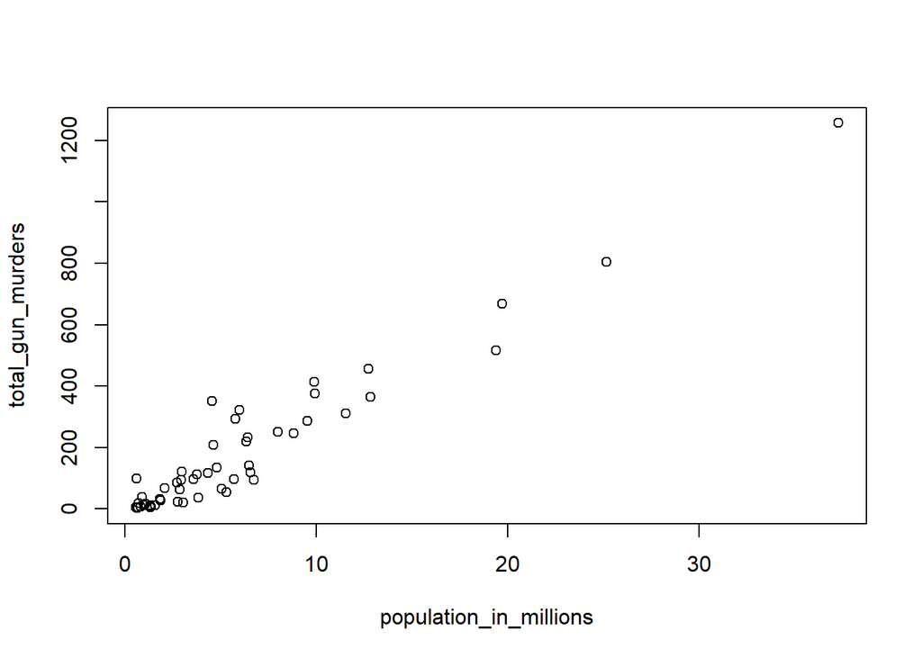

```r
  population_in_millions <- murders$population/10^6
  total_gun_murders <- murders$total
  plot(population_in_millions, total_gun_murders)
```

Perlu diingat bahwa beberapa negara bagian memiliki populasi di bawah 5 juta, sehingga untuk mempermudah analisis, buat plot dalam skala log. Transformasi nilai variabel menggunakan transformasi log10,kemudian tampilkan plot-nya.

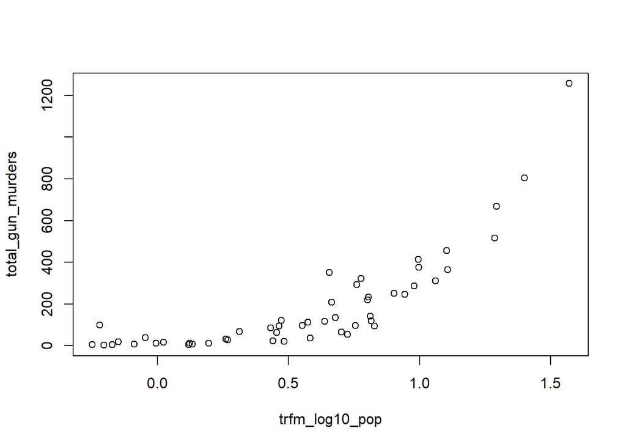

```r
  population_in_millions <- murders$population/10^6
  trfm_log10_pop <- log10(population_in_millions)
  total_gun_murders <- murders$total
  plot(trfm_log10_pop, total_gun_murders)
```

8. Buat histogram dari populasi negara bagian.

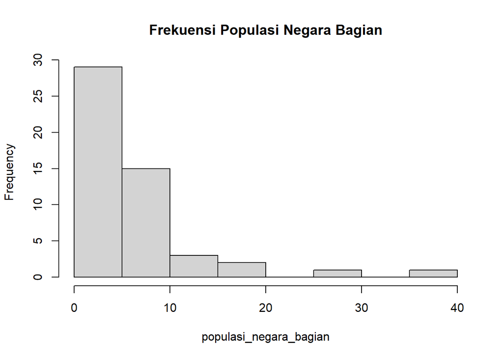

```r
  populasi_negara_bagian <- with(murders, population/10^6)
  hist(populasi_negara_bagian, main = "Frekuensi Populasi Negara Bagian")
```

9. Hasilkan boxplot dari populasi negara bagian berdasarkan wilayahnya.

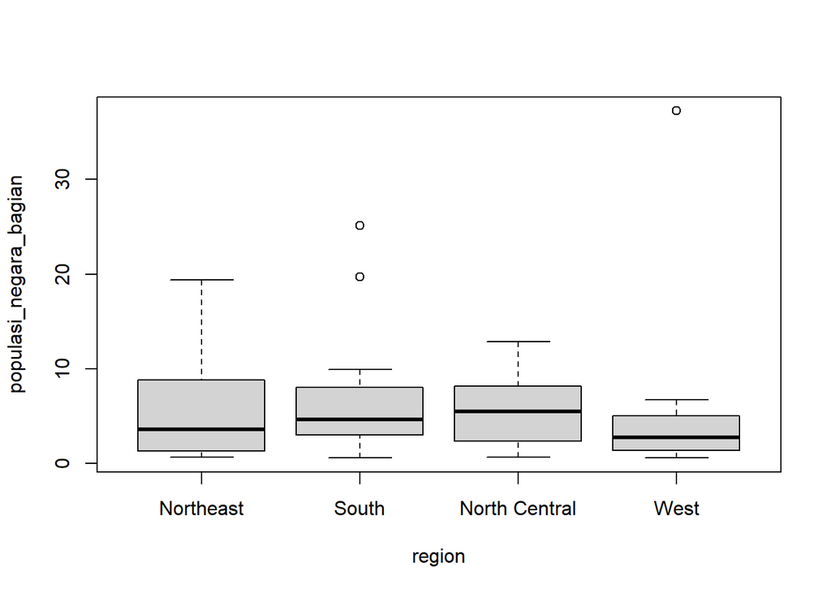

```r
  populasi_negara_bagian <- with(murders, population/10^6)
  boxplot(populasi_negara_bagian~region, data = murders)
```